# WILD 591 – Spatial Population Modeling

Lesson 6: Point Process

Mahdieh Tourani

2026-10-07

# Where we’re going

## Roadmap for today

1. Univariate point pattern analysis
2. Bivariate point pattern analysis
3. Point pattern analysis with covariates

# 1.1 Building patterns

## R Package

- The primary package for spatial point patterns in R is `spatstat`.
- `spatstat` uses three core custom classes:
  - `ppp`: Point Pattern (coordinates + marks).
  - `owin`: Observation Window (study boundaries).
  - `im`: Pixel Image (covariates or kernel densities).

```r
library(spatstat)

# spatstat was split into sub-packages c. 2022; the umbrella package
# loads them all. Where the pieces live:
#   ppp, owin, im, quadratcount, nndist   -> spatstat.geom
#   Kest, Lest, pcf, Gest, envelope       -> spatstat.explore
#   ppm, kppm, predict.ppm                -> spatstat.model
#   rpoispp, rThomas, rMatClust, rlabel   -> spatstat.random
packageVersion("spatstat")
```

## The Prickly Pear Cactus

- **Cactus species** *Opuntia humifusa* mapped in a 50x50m plot in Florida.
- **Herbivore**: Coreid bug (*Chelinidea vittiger*), a specialist insect herbivore.
- **Covariate**: Continuous matrix vegetation height (mapped at 2m spacing).

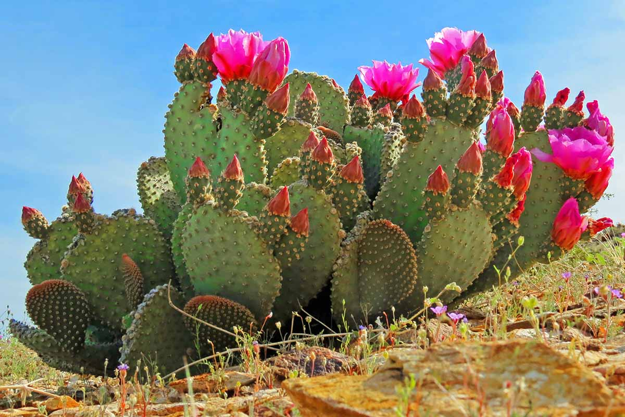

## Simulate patterns

```r
# A smooth vegetation-height surface, as a spatstat pixel image
gx <- seq(0.25, 49.75, length.out = 100)
gy <- seq(0.25, 49.75, length.out = 100)

# NOTE: im() wants rows = y, columns = x. outer(gy, gx, ...) gets this right.
veg_mat <- outer(gy, gx, function(yy, xx)
  22 + 7 * sin(xx / 8.5) + 5 * cos(yy / 11) - 0.004 * (xx - 25)^2)
cov_veg <- im(veg_mat, xcol = gx, yrow = gy)
plot(cov_veg, main = "Simulated vegetation height (cm)")
```

## An inhomogeneous Thomas process

```r
set.seed(414)
W <- owin(c(0, 50), c(0, 50))

kappa <- 0.008     # parent intensity, per m^2
mu    <- 4.6       # mean offspring per parent
sc    <- 3.7       # cluster scale, m

# parent intensity depends on vegetation height -> genuine inhomogeneity
lam_mat <- kappa * exp(0.10 * (veg_mat - mean(veg_mat)))
parents <- rpoispp(im(lam_mat, xcol = gx, yrow = gy))

# Gaussian offspring around each parent
nk <- rpois(npoints(parents), mu)
ox <- rep(parents$x, nk) + rnorm(sum(nk), 0, sc)
oy <- rep(parents$y, nk) + rnorm(sum(nk), 0, sc)
keep <- ox >= 0 & ox <= 50 & oy >= 0 & oy <= 50

cactus <- ppp(ox[keep], oy[keep], window = W)
npoints(cactus)
plot(cactus, pch = 19, cex = 0.8, main = "Simulated cactus patches")
```

## Visualization

First-order density can be estimated using a kernel smoother with a specified bandwidth.

```r
summary(cactus)

op <- par(mfrow = c(1, 2), mar = c(1, 1, 3, 3))
plot(cactus, pch = 19, cex = 0.7, main = "point locations")
#Plot kernel density intensity (bandwidth sigma)
plot(density(cactus, sigma = 3), main = "kernel intensity, sigma = 3 m")
plot(cactus, add = TRUE, pch = 19, cex = 0.4, col = "white")
par(op)
```

## Quadrat counts and a chi-square test

```r
Q <- quadratcount(cactus, nx = 4, ny = 4)   # 12.5 x 12.5 m quadrats

op <- par(mfrow = c(1, 2), mar = c(1, 1, 3, 1))
plot(cactus, pch = 19, cex = 0.7, main = "counts in 4 x 4 quadrats")
plot(Q, add = TRUE, cex = 1.2, col = "firebrick")
plot(intensity(Q, image = TRUE), main = "quadrat intensity")
par(op)

quadrat.test(cactus, nx = 4, ny = 4, method = "Chisq")
```